# Logistic Regression on German Credit dataset

**Plot gain chart and lift chart:**

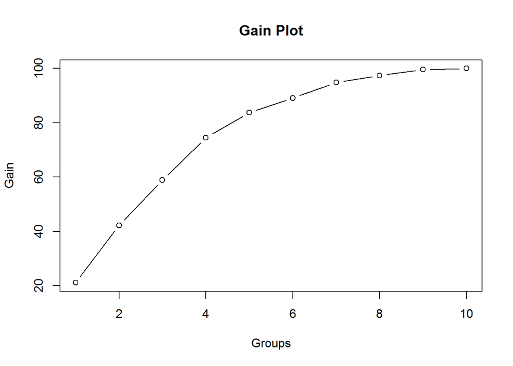

```r
#3C -> Plot the Cumulative Gain and Cumulative Lift Chart
#-------------------------------------------------------------------------------------

#Gain Chart
plot(gainTable$groups, gainTable$Gain, type="b",
     main = "Gain Plot",
     xlab = "Groups", ylab = "Gain")
```

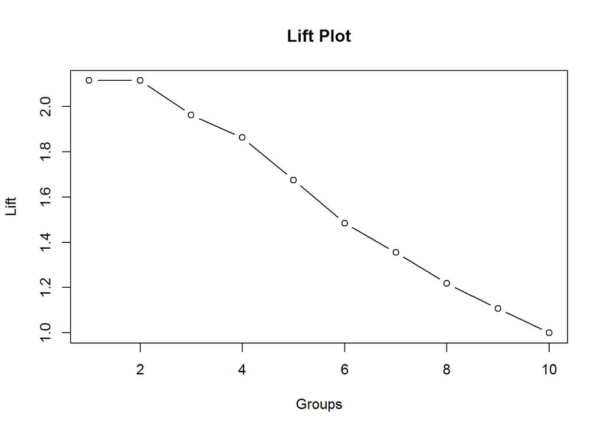

```r
#Lift Chart
plot(gainTable$groups, gainTable$Lift, type="b",
     main = "Lift Plot",
     xlab = "Groups", ylab = "Lift")
```

**KS - Statistics**

```r
#Creating an initial table
ks = sqldf("select groups, count(actual) as N, sum(actual) as N1,
           count(actual)-sum(actual) as N0 from newdata group by groups ")




#Calculate Percentage Events and Non-Events
ks$PerN0 = round(ks$N0/sum(ks$N0)*100,2)
ks$perN1 = round(ks$N1/sum(ks$N1)*100,2)


#Calculate Cumulative Percentage of Events and Non-Events
ks$CumPerN0 = cumsum(ks$PerN0)
ks$CumPerN1 = cumsum(ks$perN1)


#Calculation of KS
ks$KS = abs(ks$CumPerN0 - ks$CumPerN1)


#Print the Table
ks
```

```
##    groups   N  N1  N0 PerN0 perN1 CumPerN0 CumPerN1    KS
## 1       1 140 107  33  3.67 21.15     3.67    21.15 17.48
## 2       2 140 107  33  3.67 21.15     7.34    42.30 34.96
## 3       3 140  84  56  6.22 16.60    13.56    58.90 45.34
## 4       4 140  79  61  6.78 15.61    20.34    74.51 54.17
## 5       5 140  47  93 10.33  9.29    30.67    83.80 53.13
## 6       6 140  27 113 12.56  5.34    43.23    89.14 45.91
## 7       7 140  29 111 12.33  5.73    55.56    94.87 39.31
## 8       8 140  13 127 14.11  2.57    69.67    97.44 27.77
## 9       9 140  11 129 14.33  2.17    84.00    99.61 15.61
## 10     10 146   2 144 16.00  0.40   100.00   100.01  0.01
```

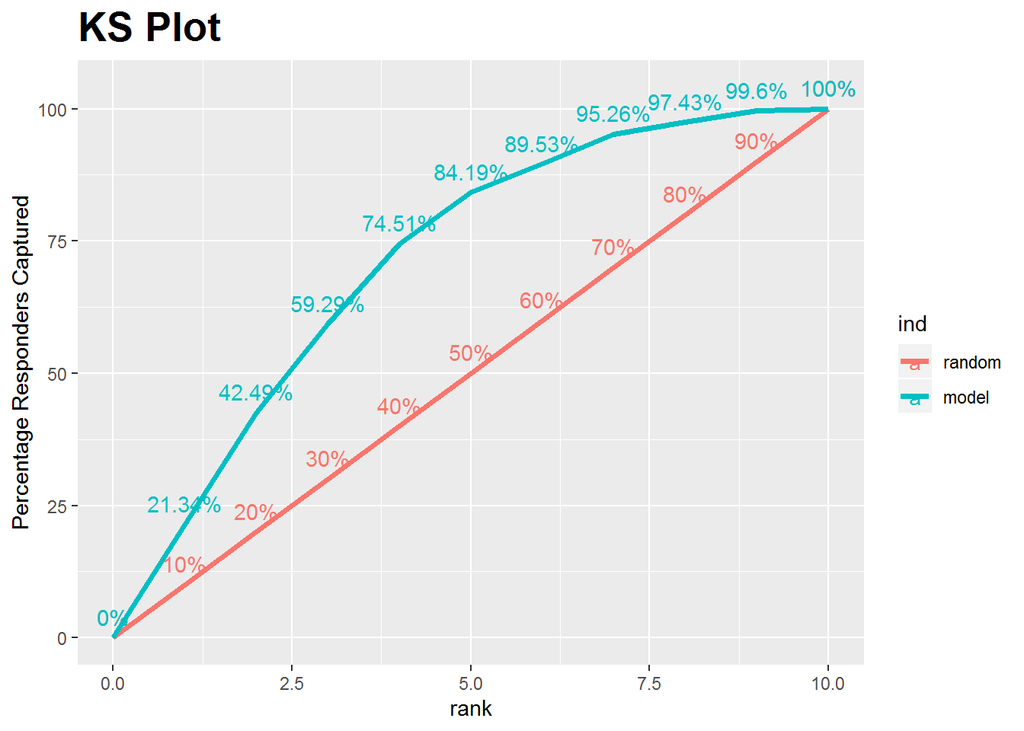

```r
#Plot the Graph
#plot(ks$groups, ks$CumPerN0, type="l", col = "Green")
#lines(ks$groups, ks$CumPerN1, col = "Red")
#plot(ks$groups, ks$cumPerN2, type="l", col="red")
#lines(ks$groups, ks$cumPerN1, col="blue")


ks_plot(newdata$actual, newdata$pred1)
```

KS also captures the discriminatory power of the model in separating “Non defaulters” from “Defaulters. It is the highest separation between the Cumulative Good Rate and Cumulative Bad Rate. Higher the KS, better is the model (higher separation between good and bad). KS values can range between 0 -100%, KS values greater than 20% are considered acceptable for a model.